# MTH6139 Time Series

Analysing Stock Market Returns in Relation To Volatility

Aaron Tahiri

Spring term 2025

# Section 1: Introduction

This report analyses financial time series data and uses Meta Prophet to forecast, in particular, We are exploring the the NASDAQ Index, and the VIX Volatility index

The NASDAQ represents the performance of technology based equities and some of the most significant stocks, which we are using to represent the general stock market, while the VIX measures expected market volatility. These two variables are closely related as we will see when we compare the 2 time series’

The aim of this project is to explore the correlations in behaviour between these time series and produce forecasts using Prophet.

# Section 2: Data Collection

The data was obtained from Yahoo Finance using the `quantmod` package, which I used daily data of the NASDAQ and VIX from the year 2000 onwards thi time period captures multiple market regimes and events, such as the dot com crash, the financial crisis, and the COVID19 pandemic.

```r
library(quantmod)
getSymbols("^IXIC", src = "yahoo", from = "2000-01-01")
```

```
## [1] "IXIC"
```

```r
getSymbols("^VIX", src = "yahoo", from = "2000-01-01")
```

```
## [1] "VIX"
```

# Section 3: Data Preparation

The data needs to be in the correct format.

```r
nasdaq <- data.frame(
  ds = index(IXIC),
  y = as.numeric(Cl(IXIC))
)

vix <- data.frame(
  ds = index(VIX),
  y = as.numeric(Cl(VIX))
)

nasdaq <- na.omit(nasdaq)
vix <- na.omit(vix)
```

# Section 4: Exploratory Data Analysis

## 4.1 NASDAQ Time Series

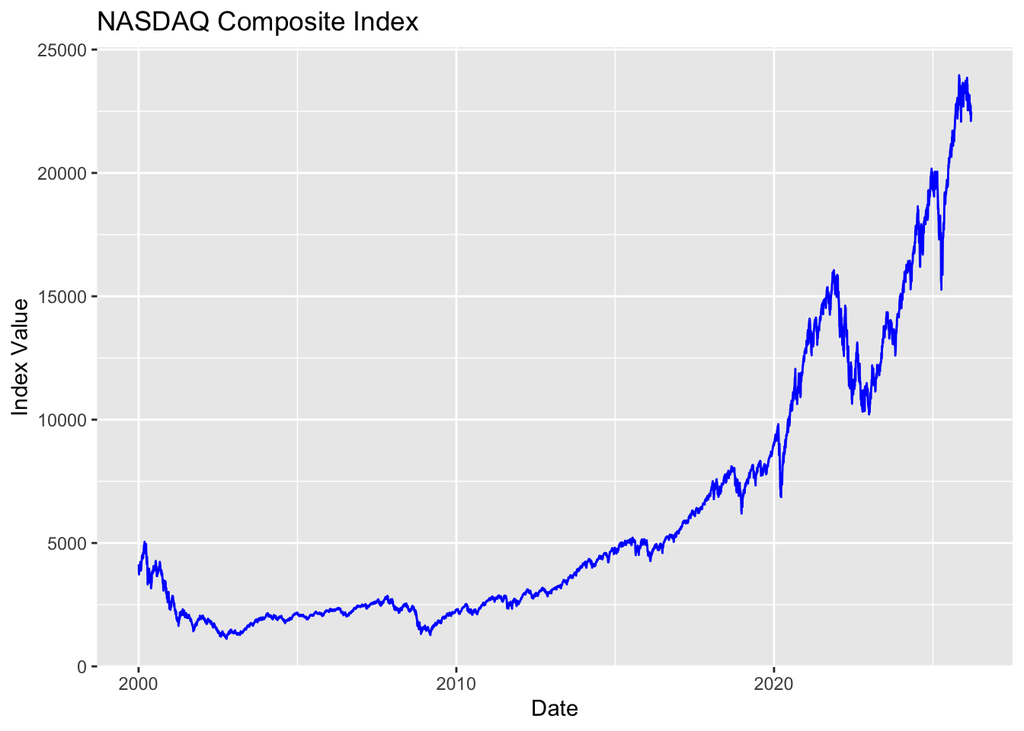

```r
library(ggplot2)

ggplot(nasdaq, aes(x = ds, y = y)) +
  geom_line(color = "blue") +
  labs(title = "NASDAQ Composite Index",
       x = "Date",
       y = "Index Value")
```

The NASDAQ shows a clear upward trend over time, with noticeable drops during major financial crises.

## 4.2 VIX Time Series

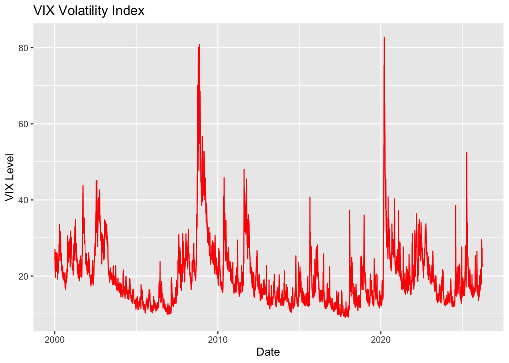

```r
ggplot(vix, aes(x = ds, y = y)) +
  geom_line(color = "red") +
  labs(title = "VIX Volatility Index",
       x = "Date",
       y = "VIX Level")
```

The VIX exhibits sharp spikes during periods of market stress, indicating increased uncertainty and volatility.

## 4.3 Combined Plot

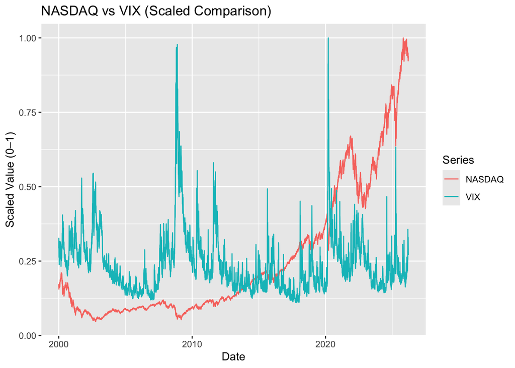

The scaled plot can show an inverse relationship between the NASDAQ and VIX. Periods of declining market performance tend to coincide with increases in volatility, reflecting higher market uncertainty. THis is wha can be seen when we look at major events.

# Section 5: Forecasting NASDAQ with Prophet

```r
library(prophet)
model_nasdaq <- prophet(nasdaq)
```

```
## Disabling daily seasonality. Run prophet with daily.seasonality=TRUE to override this.
```

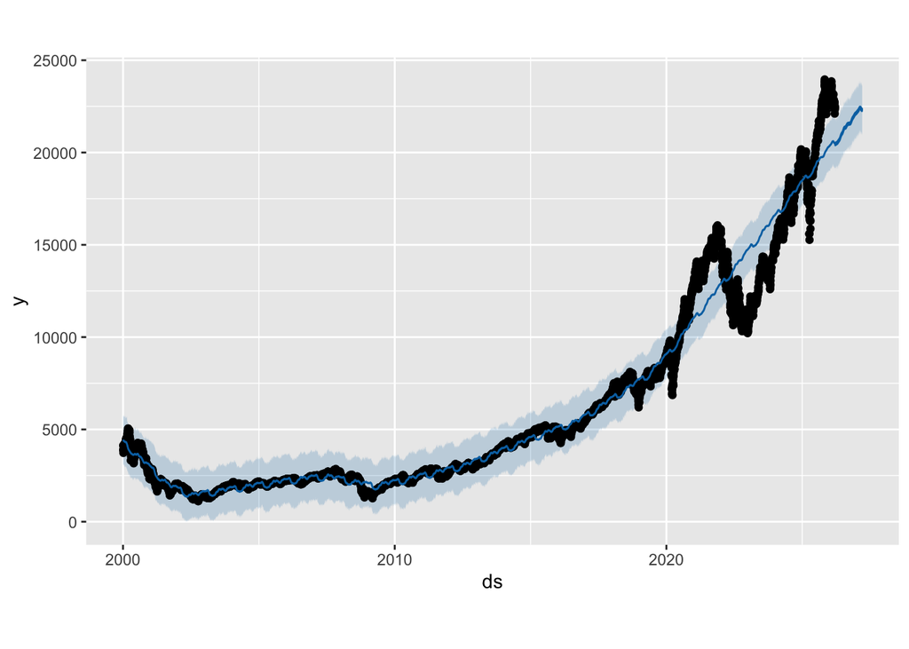

```r
future_nasdaq <- make_future_dataframe(model_nasdaq, periods = 365)
forecast_nasdaq <- predict(model_nasdaq, future_nasdaq)

plot(model_nasdaq, forecast_nasdaq)
```

The forecast shows that the NASDAQ maintains a long-term bullish trend, although short-term fluctuations remain uncertain.

# Section 6: Forecasting VIX

```r
model_vix <- prophet(vix)
```

```
## Disabling daily seasonality. Run prophet with daily.seasonality=TRUE to override this.
```

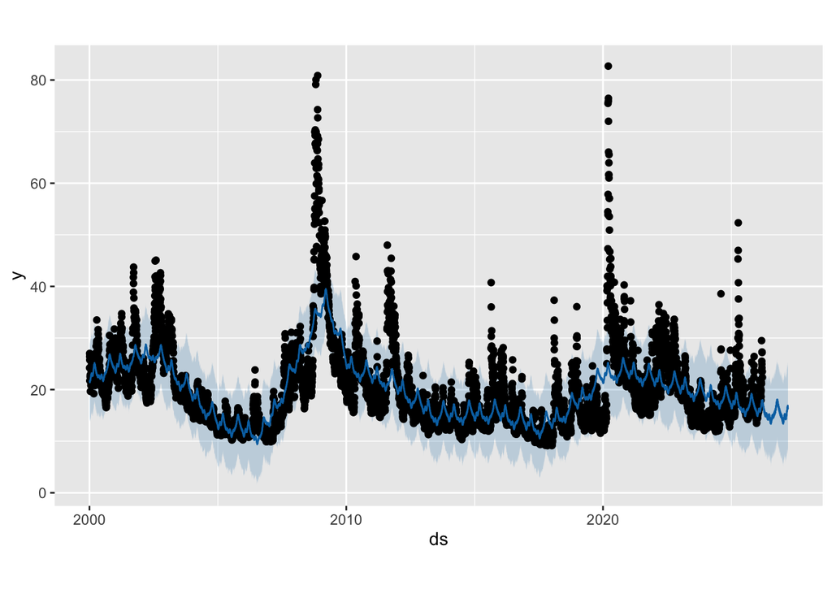

```r
future_vix <- make_future_dataframe(model_vix, periods = 365)
forecast_vix <- predict(model_vix, future_vix)

plot(model_vix, forecast_vix)
```

While we tried to forecast the VIX, I conclude that it is more difficult to forecast or predict the VIX.

# Section 7: Returns and Volatility Relationship

```r
library(dplyr)
nasdaq_returns <- nasdaq %>%
  arrange(ds) %>%
  mutate(return = c(NA, diff(log(y))))

merged_data <- nasdaq_returns %>%
  select(ds, return) %>%
  inner_join(vix, by = "ds")

colnames(merged_data) <- c("ds","return","vix")
```

Here we investigate potential relationships between returns and volatility

## 7.1 Returns Over Time

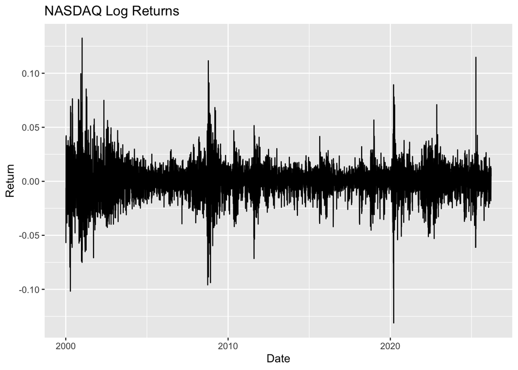

```r
ggplot(merged_data, aes(x = ds, y = return)) +
  geom_line() +
  labs(title = "NASDAQ Log Returns",
       x = "Date",
       y = "Return")
```

## 7.2 Returns vs VIX

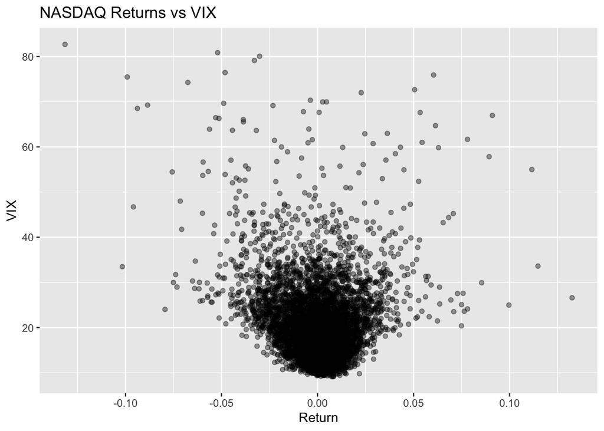

```r
ggplot(merged_data, aes(x = return, y = vix)) +
  geom_point(alpha = 0.4) +
  labs(title = "NASDAQ Returns vs VIX",
       x = "Return",
       y = "VIX")
```

# Section 8: Conclusion

This project applied Prophet to forecast financial time series data, by analysing the correlation between two financial time series

The NASDAQ shows strong long term growth, while the VIX shows periods of market stress through volatility spikes, their relationship and movements often coincide

Although Prophet effectively models long term trends, financial markets still remain difficult to predict in the short term due to their stochastic nature and the multitude of factors affecting it.

Further work could include additional variables or alternative forecasting methods.